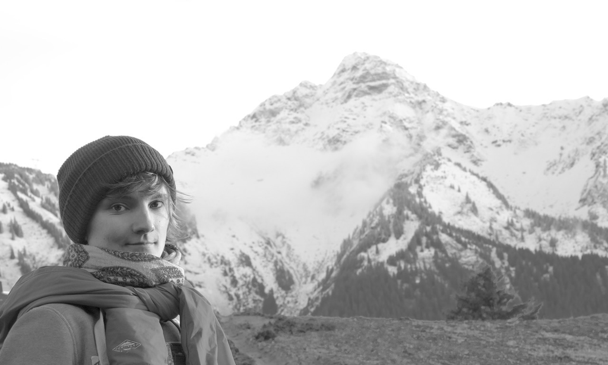

# Salomé Carcy (she/her)

Hi! I’m Salomé Carcy, a 4th year medical student at [Université Paris Cité](https://u-paris.fr/medecine/). I just completed my PhD in the [Meyer lab](https://meyer-lab-cshl.github.io/) at [Cold Spring Harbor Laboratory](https://www.cshl.edu/), where I studied how the development of different T cell lineages is regulated in the human thymus. I hope in the long run that I’ll work as a clinician-scientist, so in the meantime I continue to do a tiny bit of research in the [Paget lab](https://cepr-inserm.fr/team-4/).

Outside lab or the hospital, I like to:

- get involved in affinity groups: I volunteered in the past in [ARES](https://www.facebook.com/areslillecatho/) at the [medical school](https://fmms.fr/) of the Université Catholique de Lille to inform, encourage and accompany young medical students who would like to get involved in science; I also volunteered for two years in [DIAS](https://www.cshl.edu/research/career-development/dias/) at CSHL to promote and advocate for more diversity, equity and inclusion in STEM.
- write scientific articles for the general public: you can find an article about [senescence and telomeropathies](https://planet-vie.ens.fr/thematiques/sante/pathologies/telomeres-et-telomeropathies#:~:text=Les%20t%C3%A9lom%C3%A9ropathies%20forment%20un%20spectre,partie%20de%20l'ADN%20codant.) or about the [Human Impacts Database](https://planet-vie.ens.fr/thematiques/ecologie/human-impacts-database-la-base-de-donnees-recensant-l-impact-de-l-etre-humain)
- read graphic novels: my favorite is probably [Vie De Carabin](https://bsky.app/profile/viedecarabin.bsky.social), a doctor telling stories from his experience at the hospital.